# QK Box 6.2

Christensen et al. (1996) studied the relationships between coarse woody debris (CWD) and shoreline vegetation and lake development in a sample of 16 lakes in North America. The main variables of interest are the density of cabins (no. km<sup>−1</sup>), density of riparian trees (trees km<sup>−1</sup>), the basal area of riparian trees (m<sup>2</sup> km<sup>−1</sup>), density of coarse woody debris (no. km<sup>−1</sup>), basal area of coarse woody debris (m<sup>2</sup> km<sup>−1</sup>).

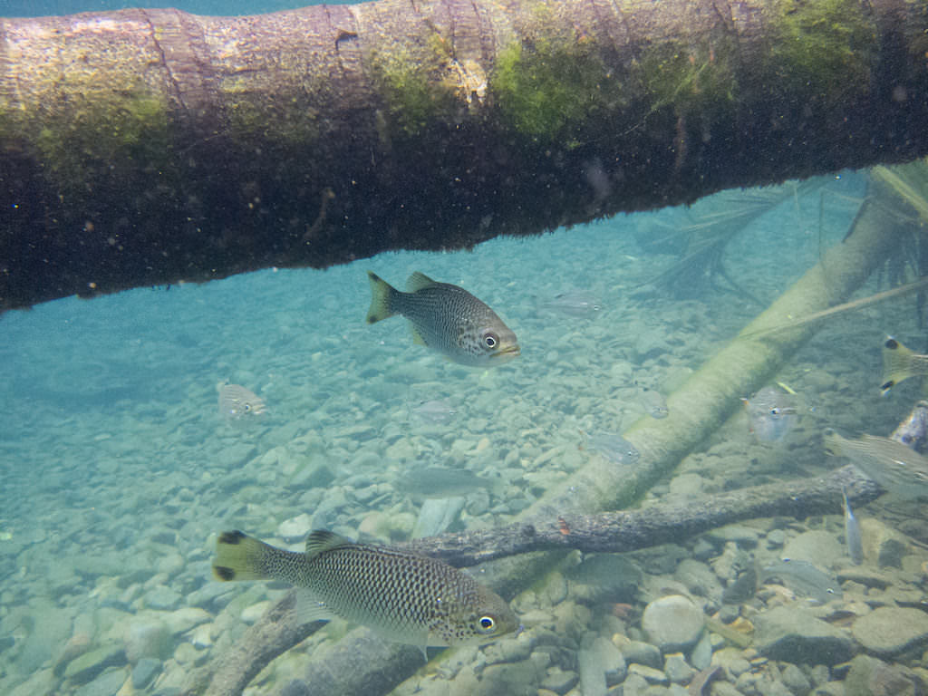

Coarse woody debris provides important habitat structure. Not quite a lake in Wisconsin, but World Heritage rainforest in northern Australia! Photo M. Keough

Christensen, D. L., Herwig, B. R., Schindler, D. E. & Carpenter, S. R. (1996). Impacts of lakeshore residential development on coarse woody debris in north temperate lakes. *Ecological Applications*, 6, 1143-49.

The original paper: https://doi.org/10.2307/2269598

This data set was used for the first edition, and is available here christ.csv

### Preliminaries

First, load the required packages (car, lm.beta).

Import Christensen data (christ.csv)

```r
christ <- read.csv("../data/christ.csv")
head(christ,10)
```

|  | lake | ripdens | cwdbasal | cabin |
| --- | --- | --- | --- | --- |
| 1 | Bay | 1270 | 121 | 0.0 |
| 2 | Bergner | 1210 | 41 | 0.0 |
| 3 | Crampton | 1800 | 183 | 0.0 |
| 4 | Long | 1875 | 130 | 0.0 |
| 5 | Roach | 1300 | 127 | 0.0 |
| 6 | Tenderfoot | 2150 | 134 | 0.6 |
| 7 | Palmer | 1330 | 65 | 1.9 |
| 8 | Street | 964 | 52 | 3.6 |
| 9 | Laura | 961 | 12 | 4.1 |
| 10 | Annabelle | 1400 | 46 | 4.8 |

### CWD versus riparian density first

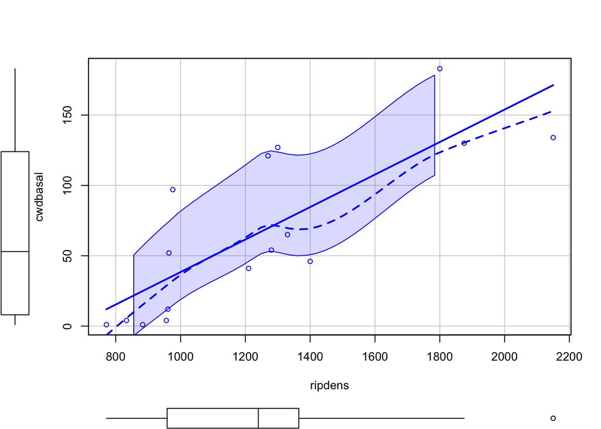

```r
scatterplot(cwdbasal~ripdens, data=christ)
```

```r
christ.lm <- lm(cwdbasal ~ ripdens, data=christ)
```

Check diagnostics

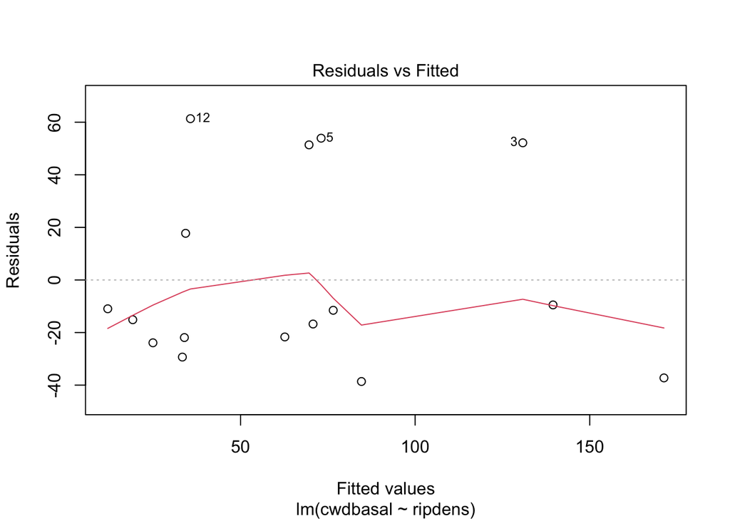

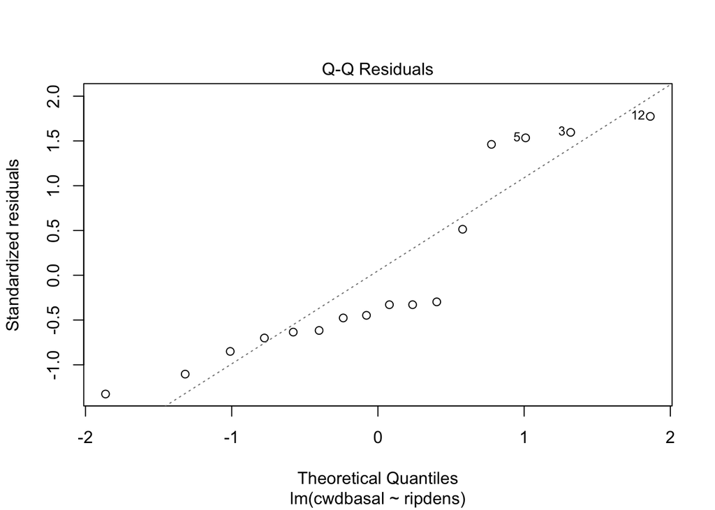

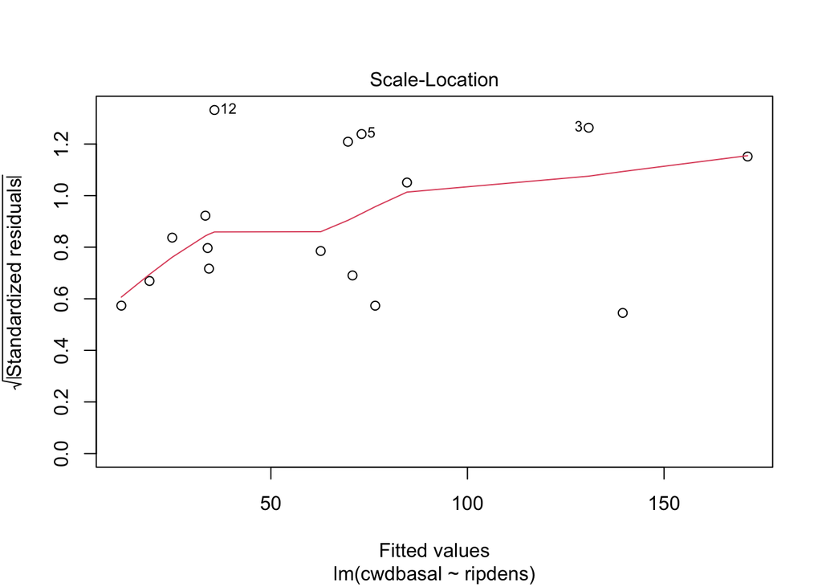

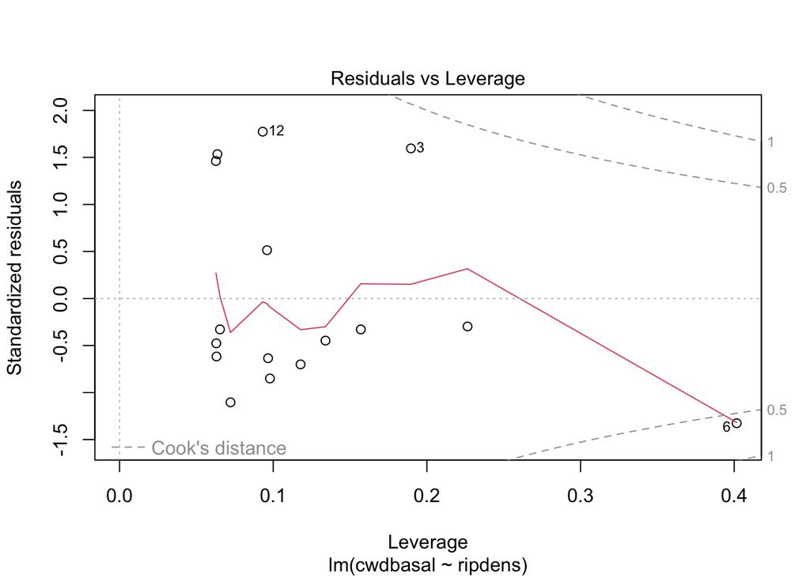

```r
plot(christ.lm)
```

```r
augment(christ.lm)
```

| cwdbasal | ripdens | .fitted | .resid | .hat | .sigma | .cooksd | .std.resid |
| --- | --- | --- | --- | --- | --- | --- | --- |
| 121 | 1270 | 69.60633 | 51.393669 | 0.06271192 | 34.69375 | 0.071475743 | 1.4616919 |
| 41 | 1210 | 62.67537 | -21.675367 | 0.06308346 | 37.17330 | 0.012799180 | -0.6165933 |
| 183 | 1800 | 130.82985 | 52.170151 | 0.18960407 | 34.08930 | 0.297874187 | 1.5957183 |
| 130 | 1875 | 139.49355 | -9.493554 | 0.22644969 | 37.56947 | 0.012929680 | -0.2972127 |
| 127 | 1300 | 73.07181 | 53.928187 | 0.06365013 | 34.37309 | 0.080036886 | 1.5345446 |
| 134 | 2150 | 171.26047 | -37.260473 | 0.40161828 | 35.24136 | 0.590322181 | -1.3263006 |
| 65 | 1330 | 76.53730 | -11.537296 | 0.06533767 | 37.54295 | 0.003773964 | -0.3285938 |
| 52 | 964 | 34.25841 | 17.741586 | 0.09594346 | 37.33156 | 0.014006984 | 0.5137803 |
| 12 | 961 | 33.91187 | -21.911866 | 0.09665516 | 37.14220 | 0.021558184 | -0.6347977 |
| 46 | 1400 | 84.62342 | -38.623420 | 0.07218930 | 36.01039 | 0.047423220 | -1.1040883 |

[output cut: 6 more lines]

Examine model output

```r
glance(christ.lm)
```

| r.squared | adj.r.squared | sigma | statistic | p.value | df | logLik | AIC | BIC | deviance | df.residual | nobs |
| --- | --- | --- | --- | --- | --- | --- | --- | --- | --- | --- | --- |
| 0.6344901 | 0.6083822 | 36.31761 | 24.30265 | 0.0002216405 | 1 | -79.11161 | 164.2232 | 166.541 | 18465.56 | 14 | 16 |

```r
tidy(christ.lm, conf.int = TRUE)
```

| term | estimate | std.error | statistic | p.value | conf.low | conf.high |
| --- | --- | --- | --- | --- | --- | --- |
| (Intercept) | -77.0990778 | 30.60800907 | -2.518918 | 0.0245520121 | -142.74672817 | -11.4514274 |
| ripdens | 0.1155161 | 0.02343233 | 4.929772 | 0.0002216405 | 0.06525871 | 0.1657734 |

```r
anova(christ.lm)
```

|  | Df | Sum Sq | Mean Sq | F value | Pr(>F) |
| --- | --- | --- | --- | --- | --- |
| ripdens | 1 | 32054.44 | 32054.439 | 24.30265 | 0.0002216405 |
| Residuals | 14 | 18465.56 | 1318.969 | NA | NA |

Get standardized coefficients

```r
lm.beta(christ.lm)
```

```
##
## Call:
## lm(formula = cwdbasal ~ ripdens, data = christ)
##
## Standardized Coefficients::
## (Intercept)     ripdens
##          NA   0.7965489
```

```r
predict(christ.lm, data.frame(ripdens=c(1500)), interval="prediction", se=T)
```

```
## $fit
##        fit      lwr     upr
## 1 96.17503 14.88709 177.463
##
## $se.fit
## [1] 10.83789
##
## $df
## [1] 14
##
## $residual.scale
## [1] 36.31761
```

### Now CWD versus cabin density

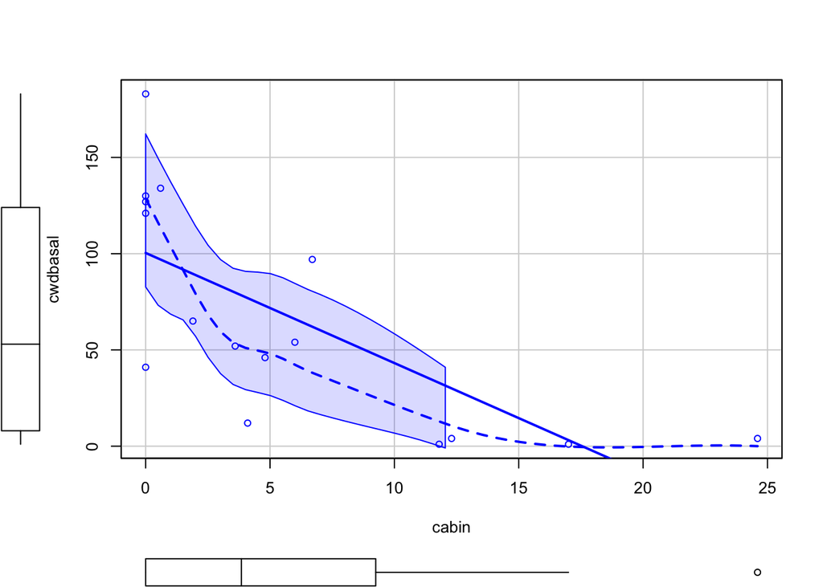

```r
scatterplot(cwdbasal~cabin, data=christ)
```

```r
christ1.lm <- lm(cwdbasal ~ cabin, data=christ)
```

Check diagnostics

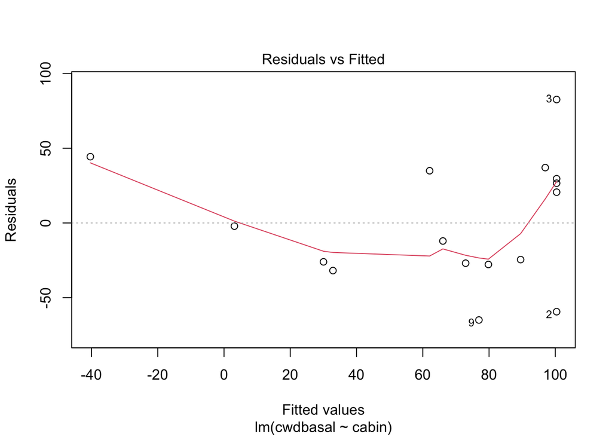

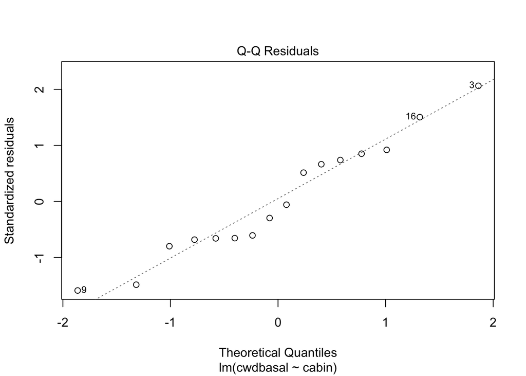

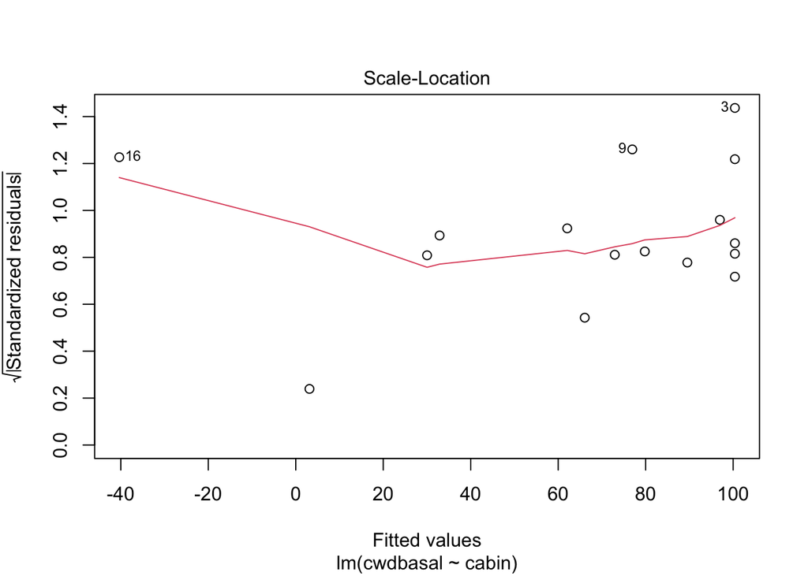

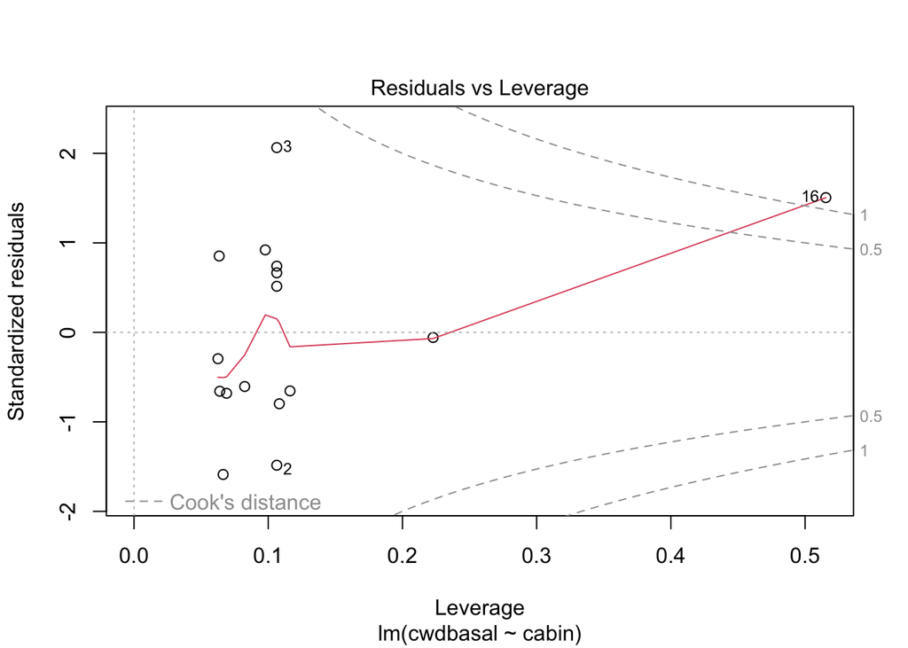

```r
plot(christ1.lm)
```

```r
augment(christ1.lm)
```

| cwdbasal | cabin | .fitted | .resid | .hat | .sigma | .cooksd | .std.resid |
| --- | --- | --- | --- | --- | --- | --- | --- |
| 121 | 0.0 | 100.399315 | 20.600685 | 0.10634862 | 43.50507 | 0.0157736264 | 0.51487157 |
| 41 | 0.0 | 100.399315 | -59.399315 | 0.10634862 | 40.31770 | 0.1311387645 | -1.48456316 |
| 183 | 0.0 | 100.399315 | 82.600685 | 0.10634862 | 36.63232 | 0.2535919817 | 2.06443348 |
| 130 | 0.0 | 100.399315 | 29.600685 | 0.10634862 | 43.05578 | 0.0325665495 | 0.73980798 |
| 127 | 0.0 | 100.399315 | 26.600685 | 0.10634862 | 43.22399 | 0.0262998859 | 0.66482917 |
| 134 | 0.6 | 96.966409 | 37.033591 | 0.09779801 | 42.57096 | 0.0459924696 | 0.92118159 |
| 65 | 1.9 | 89.528446 | -24.528446 | 0.08245002 | 43.34492 | 0.0164453821 | -0.60500153 |
| 52 | 3.6 | 79.801879 | -27.801879 | 0.06894211 | 43.18983 | 0.0171574255 | -0.68074916 |
| 12 | 4.1 | 76.941124 | -64.941124 | 0.06638465 | 39.77113 | 0.0896486833 | -1.58795107 |
| 46 | 4.8 | 72.936067 | -26.936067 | 0.06388509 | 43.23888 | 0.0147632568 | -0.65776522 |

[output cut: 6 more lines]

```r
anova(christ1.lm)
```

|  | Df | Sum Sq | Mean Sq | F value | Pr(>F) |
| --- | --- | --- | --- | --- | --- |
| cabin | 1 | 25440.12 | 25440.12 | 14.20109 | 0.002076328 |
| Residuals | 14 | 25079.88 | 1791.42 | NA | NA |

Transform cabin density to log10 (cabin density + 1) and refit model

```r
christ$lcabin <- log10(christ$cabin+1)
christ2.lm <- lm(cwdbasal ~ lcabin, data=christ)
```

Get diagnostics

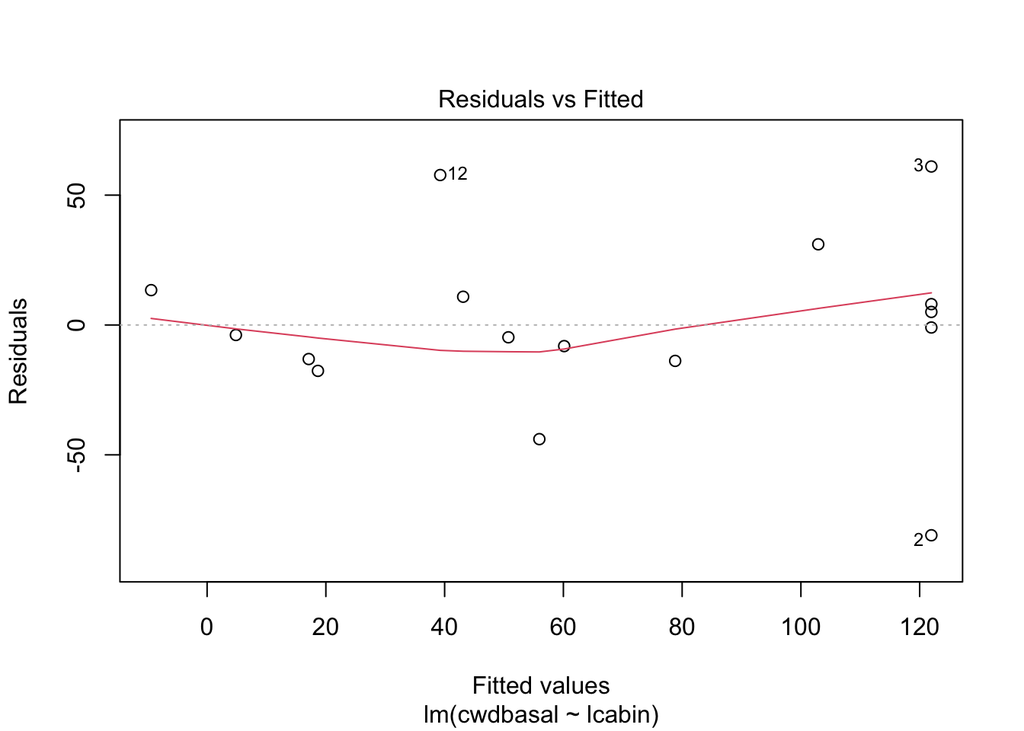

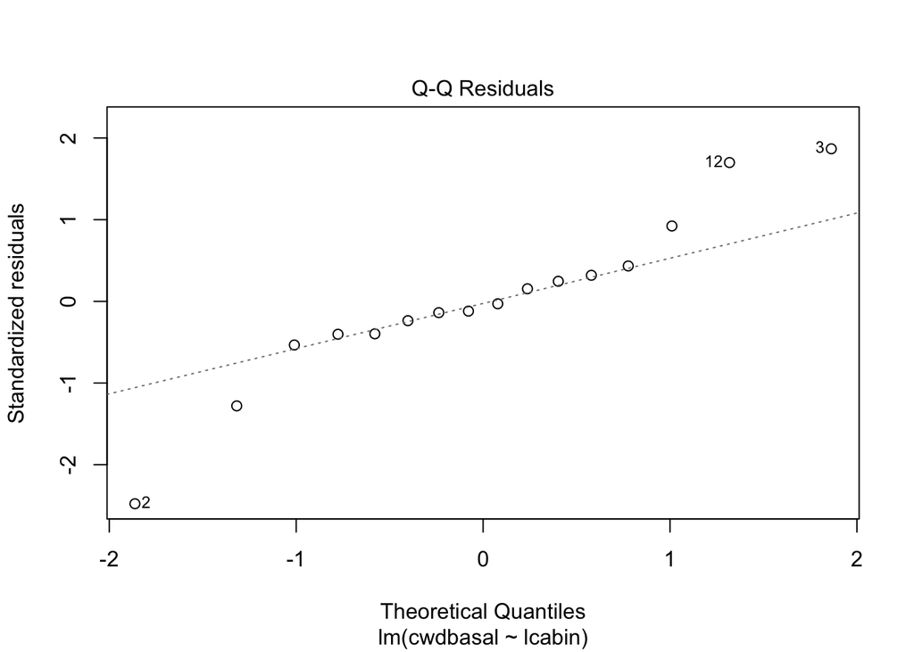

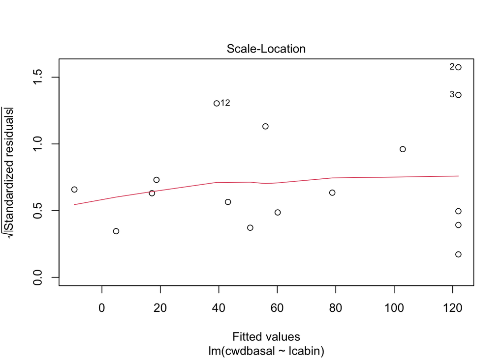

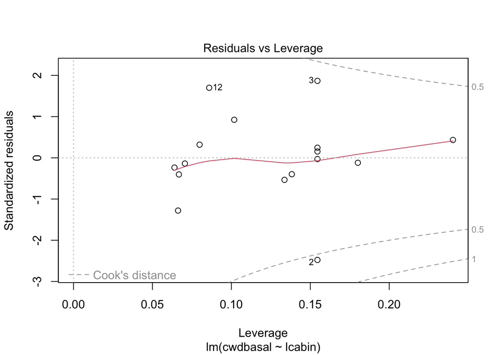

```r
plot(christ2.lm)
```

```r
augment(christ2.lm)
```

| cwdbasal | lcabin | .fitted | .resid | .hat | .sigma | .cooksd | .std.resid |
| --- | --- | --- | --- | --- | --- | --- | --- |
| 121 | 0.0000000 | 121.968746 | -0.9687458 | 0.15450910 | 36.87720 | 8.030959e-05 | -0.02964668 |
| 41 | 0.0000000 | 121.968746 | -80.9687458 | 0.15450910 | 27.63244 | 5.610254e-01 | -2.47789958 |
| 183 | 0.0000000 | 121.968746 | 61.0312542 | 0.15450910 | 31.95510 | 3.187516e-01 | 1.86774931 |
| 130 | 0.0000000 | 121.968746 | 8.0312542 | 0.15450910 | 36.79871 | 5.519687e-03 | 0.24578177 |
| 127 | 0.0000000 | 121.968746 | 5.0312542 | 0.15450910 | 36.84712 | 2.166208e-03 | 0.15397228 |
| 134 | 0.2041200 | 102.924062 | 31.0759382 | 0.10179796 | 35.73945 | 4.824486e-02 | 0.92269462 |
| 65 | 0.4623980 | 78.826356 | -13.8263564 | 0.06675894 | 36.66410 | 5.801613e-03 | -0.40274633 |
| 52 | 0.6627578 | 60.132500 | -8.1324996 | 0.06393614 | 36.80460 | 1.910711e-03 | -0.23653318 |
| 12 | 0.7075702 | 55.951444 | -43.9514443 | 0.06621715 | 34.65374 | 5.808133e-02 | -1.27988504 |
| 46 | 0.7634280 | 50.739831 | -4.7398306 | 0.07055099 | 36.85314 | 7.264223e-04 | -0.13834734 |

[output cut: 6 more lines]

Examine model output

```r
glance(christ2.lm)
```

| r.squared | adj.r.squared | sigma | statistic | p.value | df | logLik | AIC | BIC | deviance | df.residual | nobs |
| --- | --- | --- | --- | --- | --- | --- | --- | --- | --- | --- | --- |
| 0.6500362 | 0.6250387 | 35.53688 | 26.00413 | 0.0001618656 | 1 | -78.7639 | 163.5278 | 165.8456 | 17680.17 | 14 | 16 |

```r
tidy(christ2.lm, conf.int = TRUE)
```

| term | estimate | std.error | statistic | p.value | conf.low | conf.high |
| --- | --- | --- | --- | --- | --- | --- |
| (Intercept) | 121.96875 | 13.96871 | 8.731569 | 4.874864e-07 | 92.00884 | 151.92865 |
| lcabin | -93.30142 | 18.29646 | -5.099425 | 1.618656e-04 | -132.54342 | -54.05942 |

```r
anova(christ2.lm)
```

|  | Df | Sum Sq | Mean Sq | F value | Pr(>F) |
| --- | --- | --- | --- | --- | --- |
| lcabin | 1 | 32839.83 | 32839.83 | 26.00413 | 0.0001618656 |
| Residuals | 14 | 17680.17 | 1262.87 | NA | NA |

Get standardized coefficients

```r
lm.beta(christ2.lm)
```

```
##
## Call:
## lm(formula = cwdbasal ~ lcabin, data = christ)
##
## Standardized Coefficients::
## (Intercept)      lcabin
##          NA  -0.8062482
```

```r
christ$lcwd<-log10(christ$cwdbasal)
christ3.lm<-lm(christ$lcwd~christ$lcabin)
glance(christ3.lm)
```

| r.squared | adj.r.squared | sigma | statistic | p.value | df | logLik | AIC | BIC | deviance | df.residual | nobs |
| --- | --- | --- | --- | --- | --- | --- | --- | --- | --- | --- | --- |
| 0.6512274 | 0.626315 | 0.4683339 | 26.14076 | 0.0001579279 | 1 | -9.497586 | 24.99517 | 27.31294 | 3.070713 | 14 | 16 |

```r
tidy(christ3.lm)
```

| term | estimate | std.error | statistic | p.value |
| --- | --- | --- | --- | --- |
| (Intercept) | 2.194887 | 0.1840910 | 11.922834 | 1.016040e-08 |
| christ$lcabin | -1.232828 | 0.2411257 | -5.112804 | 1.579279e-04 |

```r
anova(christ3.lm)
```

|  | Df | Sum Sq | Mean Sq | F value | Pr(>F) |
| --- | --- | --- | --- | --- | --- |
| christ$lcabin | 1 | 5.733628 | 5.7336278 | 26.14076 | 0.0001579279 |
| Residuals | 14 | 3.070713 | 0.2193367 | NA | NA |